# Laboratorio 3.1: Clustering

**Autores:** Felipe Bravo-Marquez, Hernán Sarmiento, Jocelyn Dunstan, Cinthia Sánchez, Jorge Ortiz, Victor Faraggi, Alison Fernandez Blanco

**Fecha:** Mayo 2022

## ============= Declaración de compromiso ético =============

Nosotros **Sebastián Cobaise y Arturo Lazcano** , declaramos que realizamos de manera grupal los pasos de la presente actividad. También declaramos no incurrir en copia, ni compartir nuestras respuestas con otras personas ni con otros grupos. Por lo que, ratificamos que las respuestas son de nuestra propia confección y reflejan nuestro propio conocimiento.

# Instrucciones

1. Trabajen en equipos de dos personas. Salvo excepciones, no se corregirá entregas con menos de dos integrantes.
2. Modifiquen este archivo `.ipynb` agregando sus respuestas donde corresponda.
3. Cuando finalicen el laboratorio, **generen un archivo HTML** usando jupyter (ver tutorial 2) y súbanlo a U-Cursos. El laboratorio debe ser entregado sólo por 1 integrante. Si se entrega por más de un integrante, se revisará cualquiera de éstos.

# Estructura del laboratorio

Este laboratorio consiste en 2 partes. La primera son preguntas teóricas en las que no necesita escribir código y corresponden a materia vista en clases. La segunda es una sección introductoria para familiarizarse con métodos de clustering.

# Parte 1: Teoría

**1.** Explique para qué se utilizan los algoritmos de clustering.

> Respuesta: Los algoritmos de clustering se usan para identificar agrupamientos de datos que tengan cualidades parecidas o tengan alguna relación espacial, de forma simultanea se separan datos que sean distintos.

**2.** ¿Cómo podrían los algoritmos de clustering contribuir en su proyecto del curso? Describa brevemente su dataset y señale UNA aplicación posible para responder alguna pregunta sobre sus datos. Si estima que los algoritmos de clustering no servirían para su dataset, explique por qué y ejemplifique una utilidad con otro dataset.

> Respuesta: Nuestro dataset posee en cada fila un registro de un paciente covid, con información del paciente como su edad y atributos binarios (Si/No) sobre enfermedades que posee, además de una columna que determina si es que falleció o no. Aplicar un algoritmo de clustering nos puede permitir identificar conjuntos de cualidades que se manifiesten al mismo tiempo, por ejemplo, si obtuvieramos cluster bien separados, analizando sus centroides podriamos ver que enfermedades se presentan en conjunto.

**3.** Explique cómo encontrar outliers en los siguientes métodos de clustering:

- K-Means

  > Respuesta: Los datos outliers se encontrarán muy lejos de su centroide, así que si un cluster presenta un punto que al removerlo el error cuadrático (SSE) disminuye considerablemente, este dato puede considerarse outlier.
- Clustering Jerarquico Aglomerativo

  > Respuesta: Estos algoritmos van juntando puntos para armar clusters desde los más juntos hasta los más lejos, por lo que los outliers se agregarían en los últimos pasos del algoritmo, así que se encuentran facilmente.

# Parte 2: Clustering

Un amante de los pingüinos ha ido a la Antártica a recorrer las islas Biscoe, Dream y Torgersen en busca de su ave favorita. Cada vez que encontró un pingüino, anotó su sexo, su peso, la longitud de sus aletas y la longitud y profundidad de su pico.

Luego de su travesía, esta persona nos ha encargado averiguar cuántos tipos de pingüinos encontró. El desafío de este laboratorio será descubrir mediante Clustering las especies de los pingüinos de los datos recolectados.

Ejecute el siguiente código para cargar el dataset:

```python
import pandas as pd
import numpy as np
df = pd.read_csv(
    "https://ortizfuentes.com/datasets/penguins_dataset.csv", sep=",")
df.head()
```

|  | island | bill_length_mm | bill_depth_mm | flipper_length_mm | body_mass_g | sex |
| --- | --- | --- | --- | --- | --- | --- |
| 0 | Torgersen | 39.1 | 18.7 | 181.0 | 3750.0 | male |
| 1 | Torgersen | 39.5 | 17.4 | 186.0 | 3800.0 | female |
| 2 | Torgersen | 40.3 | 18.0 | 195.0 | 3250.0 | female |
| 3 | Torgersen | 36.7 | 19.3 | 193.0 | 3450.0 | female |
| 4 | Torgersen | 39.3 | 20.6 | 190.0 | 3650.0 | male |

A continuación convertiremos la información categórica en vectores de 1 y 0. Para ello utilizaremos la técnica One Hot Encoding con la información de la isla fueron vistos los pingüinos y su sexo. Finalmente concatenaremos estos vectores al DataFrame original y eliminaremos las columnas con datos categóricos.

```python
df_island = pd.get_dummies(df['island'], prefix='island', prefix_sep='_')
df_sex = pd.get_dummies(df['sex'], prefix='sex',
                        prefix_sep='_', drop_first=True)

X = pd.concat([df, df_island, df_sex], axis=1).drop(
    'sex', axis=1).drop('island', axis=1)
X.head()
```

|  | bill_length_mm | bill_depth_mm | flipper_length_mm | body_mass_g | island_Biscoe | island_Dream | island_Torgersen | sex_male |
| --- | --- | --- | --- | --- | --- | --- | --- | --- |
| 0 | 39.1 | 18.7 | 181.0 | 3750.0 | 0 | 0 | 1 | 1 |
| 1 | 39.5 | 17.4 | 186.0 | 3800.0 | 0 | 0 | 1 | 0 |
| 2 | 40.3 | 18.0 | 195.0 | 3250.0 | 0 | 0 | 1 | 0 |
| 3 | 36.7 | 19.3 | 193.0 | 3450.0 | 0 | 0 | 1 | 0 |
| 4 | 39.3 | 20.6 | 190.0 | 3650.0 | 0 | 0 | 1 | 1 |

## K-Means

**1.** Primero intentaremos encontrar la cantidad de especies de pingüinos en los datos usando K-Means. Cuando usamos esta técnica debemos definir previamente el número de clusters que queremos generar. Teniendo en cuenta estos datos, implemente un método que nos permita determinar cuántos clusters usar.

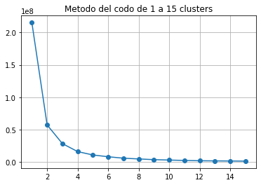

```python
# Respuesta
from sklearn.cluster import KMeans
import matplotlib.pyplot as plt
random_state = 420
sse = []

clusters = list(range(1, 16))
for k in clusters:
    kmeans = KMeans(n_clusters=k, random_state=random_state).fit(X)
    sse.append(kmeans.inertia_)

plt.plot(clusters, sse, marker="o")
plt.title("Metodo del codo de 1 a 15 clusters")
plt.grid(True)
plt.show()
```

**2.** ¿Cuántos clusters propone usar para este dataset? Justifique su elección y recuerde que hay varias respuestas posibles.

> Respuesta: Graficando kmeans para distintos números de cluster y haciendo uso del método del codo podemos observar que para 3 clusters, el descenso del error cuadrático no disminuye significativamente. Es por esto que 3 clusters parece una decisión razonable.

**3.** Entrene un modelo de K-Means usando el número de clusters que eligió en la pregunta anterior e imprima las asignaciones de clusters para cada dato.

```python
# Respuesta
kmeans = KMeans(n_clusters=3, n_init=20, max_iter=300)
kmeans.fit(X)
y_pred = kmeans.predict(X)
print(y_pred)
```

```
[1 1 1 1 1 1 0 1 1 0 1 1 0 1 0 1 1 1 1 1 1 1 1 1 1 1 1 1 1 1 0 1 1 1 0 1 1
 1 0 1 0 1 1 0 1 0 1 0 1 1 1 1 1 1 1 0 1 0 1 1 1 0 1 0 1 1 1 0 1 0 1 1 1 1
 1 0 1 0 1 1 1 1 1 1 1 0 1 0 1 0 1 0 1 0 1 0 1 0 1 1 1 1 1 0 1 0 1 0 1 0 1
 1 1 1 1 1 1 1 1 1 1 0 1 1 1 1 1 0 1 1 1 1 1 0 1 1 1 1 1 1 0 1 1 1 1 1 0 2
 0 2 2 0 0 2 0 2 0 2 0 2 0 2 0 2 0 2 2 2 0 2 2 2 2 0 2 2 0 2 2 2 2 0 2 0 2
 1 2 0 0 2 0 0 2 2 2 0 2 0 2 0 2 0 2 0 2 0 2 0 2 0 2 2 0 2 0 2 2 2 0 2 0 2
 0 2 0 2 0 2 0 2 0 2 0 2 0 2 0 2 0 2 0 0 0 2 0 2 2 2 2 0 2 0 2 2 2 0 2 0 2
 2 0 0 2 2 2 1 1 1 1 1 1 1 1 0 1 1 1 1 0 1 0 1 1 1 0 1 1 1 1 1 0 1 1 1 0 1
 0 1 0 1 1 1 0 1 0 1 1 1 1 1 0 1 0 1 1 1 1 1 0 1 1 1 0 1 1 1 1 1 1 1 1 0 1]
```

**4.** Al ejecutar el código anterior (pregunta 3) varias veces, obtenemos resultados diferentes. ¿Cómo podría evitar los resultados variables de K-means? Presente al menos 2 opciones para lograr esto. Puede implementarlo o describirlo.

> Respuesta: Para obtener siempre los mismos resultados y hacer este algoritmo replicable, podemos hacer uso del parámetro random_state que recibe un valor, y dependiendo de este los resultados serán fijos. Otra opción para evitar resultados variables ejecutar el algoritmo kmeans varias veces y nos quedamos con el resultado que entregue menor error cuadrático.

```python
# Implementación de kmeans con random_state
kmeans = KMeans(n_clusters=3, n_init=20, max_iter=300, random_state=10)
kmeans.fit(X)
y_pred = kmeans.predict(X)
print(y_pred)
```

```
[1 1 1 1 1 1 2 1 1 2 1 1 2 1 2 1 1 1 1 1 1 1 1 1 1 1 1 1 1 1 2 1 1 1 2 1 1
 1 2 1 2 1 1 2 1 2 1 2 1 1 1 1 1 1 1 2 1 2 1 1 1 2 1 2 1 1 1 2 1 2 1 1 1 1
 1 2 1 2 1 1 1 1 1 1 1 2 1 2 1 2 1 2 1 2 1 2 1 2 1 1 1 1 1 2 1 2 1 2 1 2 1
 1 1 1 1 1 1 1 1 1 1 2 1 1 1 1 1 2 1 1 1 1 1 2 1 1 1 1 1 1 2 1 1 1 1 1 2 0
 2 0 0 2 2 0 2 0 2 0 2 0 2 0 2 0 2 0 0 0 2 0 0 0 0 2 0 0 2 0 0 0 0 2 0 2 0
 1 0 2 2 0 2 2 0 0 0 2 0 2 0 2 0 2 0 2 0 2 0 2 0 2 0 0 2 0 2 0 0 0 2 0 2 0
 2 0 2 0 2 0 2 0 2 0 2 0 2 0 2 0 2 0 2 2 2 0 2 0 0 0 0 2 0 2 0 0 0 2 0 2 0
 0 2 2 0 0 0 1 1 1 1 1 1 1 1 2 1 1 1 1 2 1 2 1 1 1 2 1 1 1 1 1 2 1 1 1 2 1
 2 1 2 1 1 1 2 1 2 1 1 1 1 1 2 1 2 1 1 1 1 1 2 1 1 1 2 1 1 1 1 1 1 1 1 2 1]
```

**5.** Ejecute el siguiente código para reducir la dimensionalidad de los datos de 8 a 2. Grafique los datos transformados y pinte los gráficos para tener una representación visual de los clusters.

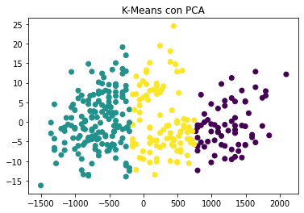

```python
from sklearn.decomposition import PCA
new_X = PCA(n_components=2, random_state=0).fit_transform(X)
plt.scatter(new_X[:, 0], new_X[:, 1], c=kmeans.labels_)
plt.title("K-Means con PCA")
plt.show()
```

## Clustering Jerárquico Aglomerativo

**6.** Usando los datos anteriores, ejecute cada uno de los 4 métodos de clustering jerárquico: complete, single, average y ward, y visualice los dendrogramas formados. Adjunte el código necesario. No necesita generar los 4 dendrogramas en el mismo gráfico, pueden ser distintos.

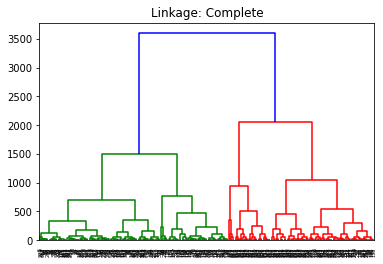

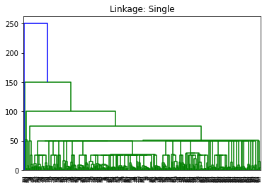

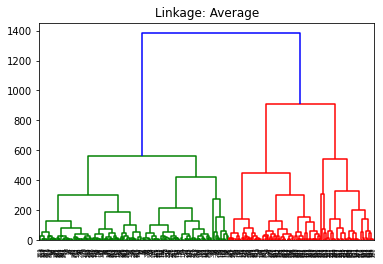

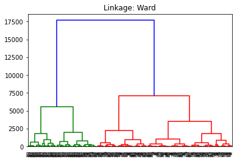

```python
# Respuesta
# Asumimos que se usan los datos de X y no de new_X
from scipy.cluster.hierarchy import dendrogram, linkage
from sklearn.cluster import AgglomerativeClustering
complete = linkage(X, method="complete")
single = linkage(X, method="single")
average = linkage(X, method="average")
ward = linkage(X, method="ward")
dendrogram(complete)
plt.title("Linkage: Complete")
plt.show()
dendrogram(single)
plt.title("Linkage: Single")
plt.show()
dendrogram(average)
plt.title("Linkage: Average")
plt.show()
dendrogram(ward)
plt.title("Linkage: Ward")
plt.show()
```

**7.** Fijándose en el método `complete`, ¿"visualmente" cuántos clusters propone usar? ¿A qué altura recomendaría cortar el árbol?

> Respuesta: Visualmente se propone usar 3 clusters, para esto se recomienda cortar el árbol a la altura 1800.

**8.** Ahora si miramos el método `ward`, "visualmente" cuántos clusters propone usar? A qué altura se debe cortar el arbol para obtener esa cantidad de clusters?

> Respuesta: Visualmente se propone usar 2 clusters para el método ward, esto pues llega un punto en que las divisiónes ocurren más seguido para alturas $\leq$ 7500 por lo que se recomienda un corte a una altura de 10.000 aprox.

**9.** Implemente el código para asignar clusters a los datos siguiendo lo que usted propuso en la pregunta **7** y **8** y liste la asignación de clusters para cada punto del dataset para `complete` y `ward`. Cuántos clusters se generan para el método `complete` cortando a la altura que propuso en la pregunta **7**?

```python
# Respuesta
complete_3 = AgglomerativeClustering(n_clusters=None, linkage="complete",distance_threshold=1800).fit(X)
print('número de clusters (método complete): ',complete_3.n_clusters_)
print(complete_3.labels_)
ward_3 = AgglomerativeClustering(n_clusters=None, linkage="ward", distance_threshold=10000).fit(X)
print('número de clusters (método ward): ',ward_3.n_clusters_)
print(ward_3.labels_)
```

```
número de clusters (método complete):  3
[0 0 0 0 0 0 1 0 0 1 0 0 1 0 0 0 0 0 0 0 0 0 0 0 0 0 0 0 0 0 0 0 0 0 1 0 0
 0 1 0 1 0 0 0 0 1 0 0 0 0 0 0 0 0 0 1 0 0 0 0 0 0 0 1 0 0 0 0 0 1 0 0 0 0
 0 1 0 0 0 0 0 0 0 0 0 1 0 1 0 1 0 1 0 0 0 1 0 1 0 0 0 0 0 1 0 1 0 1 0 0 0
 0 0 0 0 0 0 0 0 0 0 1 0 0 0 0 0 1 0 0 0 0 0 1 0 0 0 0 0 0 1 0 0 0 0 0 1 2
 1 2 2 1 1 1 1 1 1 2 1 2 0 2 0 2 1 2 2 1 1 1 1 1 2 1 2 1 1 1 2 1 2 1 1 1 2
 0 2 1 1 2 1 0 2 1 1 1 1 1 1 1 1 1 1 1 2 0 1 1 2 1 2 2 1 2 1 1 1 1 1 2 1 2
 1 2 1 2 1 2 1 2 1 1 1 2 1 2 1 2 1 1 1 1 1 1 1 2 1 2 2 1 2 1 2 1 2 1 2 1 2
 2 1 1 2 1 2 0 0 0 0 0 0 0 0 0 0 0 0 0 0 0 0 0 0 0 1 0 0 0 0 0 0 0 0 0 1 0
 1 0 0 0 0 0 1 0 1 0 0 0 0 0 1 0 1 0 0 0 0 0 0 0 0 0 0 0 0 0 0 0 0 0 0 0 0]
número de clusters (método ward):  2
[0 0 0 0 0 0 1 0 0 0 0 0 0 0 0 0 0 0 0 0 0 0 0 0 0 0 0 0 0 0 0 0 0 0 1 0 0
 0 0 0 1 0 0 0 0 0 0 0 0 0 0 0 0 0 0 0 0 0 0 0 0 0 0 0 0 0 0 0 0 0 0 0 0 0
 0 1 0 0 0 0 0 0 0 0 0 0 0 0 0 0 0 0 0 0 0 1 0 0 0 0 0 0 0 1 0 1 0 0 0 0 0
 0 0 0 0 0 0 0 0 0 0 0 0 0 0 0 0 0 0 0 0 0 0 0 0 0 0 0 0 0 0 0 0 0 0 0 0 1
 0 1 1 1 1 1 0 1 1 1 1 1 0 1 0 1 1 1 1 1 0 1 1 1 1 1 1 1 1 1 1 1 1 1 1 0 1
 0 1 0 1 1 1 0 1 1 1 1 1 0 1 1 1 0 1 0 1 0 1 0 1 1 1 1 1 1 1 1 1 1 1 1 1 1
 1 1 1 1 1 1 1 1 1 1 1 1 1 1 1 1 1 1 1 1 1 1 1 1 1 1 1 1 1 1 1 1 1 1 1 0 1
 1 1 1 1 1 1 0 0 0 0 0 0 0 0 0 0 0 0 0 0 0 0 0 0 0 0 0 0 0 0 0 0 0 0 0 1 0
 0 0 0 0 0 0 1 0 0 0 0 0 0 0 0 0 0 0 0 0 0 0 0 0 0 0 0 0 0 0 0 0 0 0 0 0 0]
```

**10.** ¿Cuántos datos quedan asignados a cada cluster? Agregue el código necesario para objener esta información para los métodos `complete` y `ward`.

```python
# Respuesta
counts1 = np.bincount(complete_3.labels_)
counts2 = np.bincount(ward_3.labels_)
print('Datos asociados a cada cluster para el método complete: ',counts1)
print('Datos asociados a cada cluster para el método ward: ',counts2)
```

```
Datos asociados a cada cluster para el método complete:  [188 103  42]
Datos asociados a cada cluster para el método ward:  [221 112]
```

**11.** Usando el dataset con dimensiones reducidas generado en la parte K-means (`new_X`), grafique los datos y píntelos con su asignacion de clusters según los métodos `complete` y `ward` para tener una representación visual de los clusters.

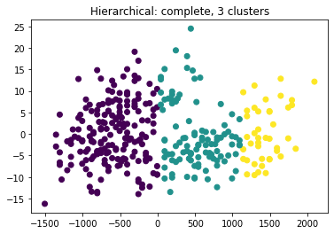

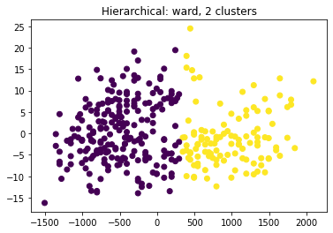

```python
# Respuesta
plt.scatter(new_X[:, 0], new_X[:, 1], c=complete_3.labels_)
plt.title("Hierarchical: complete, 3 clusters")
plt.show()
plt.scatter(new_X[:, 0], new_X[:, 1], c=ward_3.labels_)
plt.title("Hierarchical: ward, 2 clusters")
plt.show()
```

## Evaluación de los modelos

**12.** Un experto en pingüinos ha analizado los datos y ha determinado que los pingüinos encontrados corresponden a 3 tipos de especies: Adelie, Gentoo y Chinstrap. Compare la clasificación del experto con los resultados de al menos dos de sus modelos de clustering.

Hint: puede usar los métodos [groupby](https://pandas.pydata.org/pandas-docs/stable/reference/api/pandas.DataFrame.groupby.html) y value_counts de pandas para comparar los datos de las tablas. No es necesario que implementen métricas de comparación, pues se verán más adelante en el curso.

[figure not shown]

```python
df_s = pd.read_csv("https://ortizfuentes.com/datasets/penguins_species.csv", sep=",")
df_s.value_counts()
```

```
species
Adelie       146
Gentoo       119
Chinstrap     68
dtype: int64
```

Agregaremos las columnas del experto y de dos métodos de clustering usados (kmeans y ward), esto para trabajar un dataframe que solo posea estas columnas con el objetivo de contar valores etiquetados por cluster y comparar con los datos del experto.

```python
X["experto"]=df_s
X["pred_kmeans"]=y_pred
X["pred_ward"]=ward_3.labels_
X
```

|  | bill_length_mm | bill_depth_mm | flipper_length_mm | body_mass_g | island_Biscoe | island_Dream | island_Torgersen | sex_male | experto | pred_kmeans | pred_ward |
| --- | --- | --- | --- | --- | --- | --- | --- | --- | --- | --- | --- |
| 0 | 39.1 | 18.7 | 181.0 | 3750.0 | 0 | 0 | 1 | 1 | Adelie | 1 | 0 |
| 1 | 39.5 | 17.4 | 186.0 | 3800.0 | 0 | 0 | 1 | 0 | Adelie | 1 | 0 |
| 2 | 40.3 | 18.0 | 195.0 | 3250.0 | 0 | 0 | 1 | 0 | Adelie | 1 | 0 |
| 3 | 36.7 | 19.3 | 193.0 | 3450.0 | 0 | 0 | 1 | 0 | Adelie | 1 | 0 |
| 4 | 39.3 | 20.6 | 190.0 | 3650.0 | 0 | 0 | 1 | 1 | Adelie | 1 | 0 |
| ... | ... | ... | ... | ... | ... | ... | ... | ... | ... | ... | ... |
| 328 | 55.8 | 19.8 | 207.0 | 4000.0 | 0 | 1 | 0 | 1 | Chinstrap | 1 | 0 |
| 329 | 43.5 | 18.1 | 202.0 | 3400.0 | 0 | 1 | 0 | 0 | Chinstrap | 1 | 0 |
| 330 | 49.6 | 18.2 | 193.0 | 3775.0 | 0 | 1 | 0 | 1 | Chinstrap | 1 | 0 |
| 331 | 50.8 | 19.0 | 210.0 | 4100.0 | 0 | 1 | 0 | 1 | Chinstrap | 2 | 0 |
| 332 | 50.2 | 18.7 | 198.0 | 3775.0 | 0 | 1 | 0 | 0 | Chinstrap | 1 | 0 |

333 rows × 11 columns

```python
df=X[['experto','pred_kmeans']]
df.value_counts().to_frame().sort_values(by=['experto'])
```

| experto | pred_kmeans | 0 |
| --- | --- | --- |
| Adelie | 1 | 112 |
|  | 2 | 34 |
| Chinstrap | 1 | 53 |
|  | 2 | 15 |
| Gentoo | 0 | 68 |
|  | 2 | 50 |
|  | 1 | 1 |

```python
dff=X[['experto','pred_ward']]
dff.value_counts().to_frame().sort_values(by=['experto'])
```

| experto | pred_ward | 0 |
| --- | --- | --- |
| Adelie | 0 | 139 |
|  | 1 | 7 |
| Chinstrap | 0 | 66 |
|  | 1 | 2 |
| Gentoo | 1 | 103 |
|  | 0 | 16 |

**13.** Seleccione alguno de los métodos de clustering aplicados anteriormente e interprete los clusters obtenidos.

- a) ¿Qué puede decir de los clusters generados? ¿Cómo se comportan en comparación al anotado del experto?
- b) ¿Por qué el etiquetado del experto difiere de los clusters encontrados por su modelo?

> Respuesta:
- a) Para el método de kmeans, todos los pingüinos etiquetados en el cluster 0 son Gentoo con bastante error en el etiquetado (51 datos fuera de el cluster correcto). Por otro lado, las especies Adelie y Chinstrap ambas comparten el mismo cluster, lo cual no es bueno pues no nos permite etiquetar estas especies por separado, que es lo que se quiere hacer dado el estudio del experto.  
  Para el método ward, pareciera etiquetar bien los datos. Nuevamente la especie Gentoo corresponde a un cluster y posee menos error que en kmeans, sin embargo, Adelie y Chinstrap comparten el cluster 0, haciendo imposible la identificación de cada especie. Esto no es un buen indicio dado el estudio del experto pues entrega 3 especies diferentes mientras que en el método ward hay solo 2 clusters.
- b) Sobre el método ward, la altura en la que se produce el corte hace variar el número de clusters generando así resultados distintos. En nuestro caso, elegir solo 2 clusters hace que hayan 2 especies a las cuales no podemos distinguir. Por otro lado, en el método de kmeans, a pesar que posee la correcta cantidad de clusters (esto pues sabemos que el experto divide los pingüinos en 3 especies), probablemente la forma de estos clusters no es la óptima para el algoritmo kmeans.

```python
%%shell
jupyter nbconvert --to html /content/Laboratorio_3_1_actualizado (1).ipynb
```

[output not shown]

[output not shown]